# Exploratory Data Analysis - Retail

## Spark Foundation Task Specifications

- Perform ‘Exploratory Data Analysis’ on dataset ‘SampleSuperstore’
- As a business manager, try to find out the weak areas where you can work to make more profit.
- What all business problems you can derive by exploring the data?

### Importing Libraries and Data

#### Importing Libraries

```python
import pandas as pd
import numpy as np
import matplotlib.pyplot as plt
%matplotlib inline
import seaborn as sb
sb.set_theme()

import warnings
warnings.filterwarnings('ignore')
```

```python
df = pd.read_csv('SampleSuperstore.csv')
```

### Assessing, Exploring, & Understanding the Data

```python
df.head()
```

|  | Ship Mode | Segment | Country | City | State | Postal Code | Region | Category | Sub-Category | Sales | Quantity | Discount | Profit |
| --- | --- | --- | --- | --- | --- | --- | --- | --- | --- | --- | --- | --- | --- |
| 0 | Second Class | Consumer | United States | Henderson | Kentucky | 42420 | South | Furniture | Bookcases | 261.9600 | 2 | 0.00 | 41.9136 |
| 1 | Second Class | Consumer | United States | Henderson | Kentucky | 42420 | South | Furniture | Chairs | 731.9400 | 3 | 0.00 | 219.5820 |
| 2 | Second Class | Corporate | United States | Los Angeles | California | 90036 | West | Office Supplies | Labels | 14.6200 | 2 | 0.00 | 6.8714 |
| 3 | Standard Class | Consumer | United States | Fort Lauderdale | Florida | 33311 | South | Furniture | Tables | 957.5775 | 5 | 0.45 | -383.0310 |
| 4 | Standard Class | Consumer | United States | Fort Lauderdale | Florida | 33311 | South | Office Supplies | Storage | 22.3680 | 2 | 0.20 | 2.5164 |

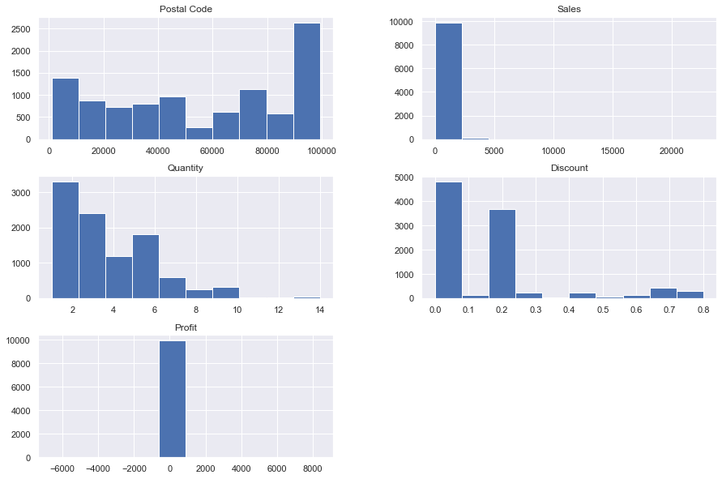

```python
df.hist(figsize=(15,10));
```

```python
df.info()
```

```
<class 'pandas.core.frame.DataFrame'>
RangeIndex: 9994 entries, 0 to 9993
Data columns (total 13 columns):
 #   Column        Non-Null Count  Dtype
---  ------        --------------  -----
 0   Ship Mode     9994 non-null   object
 1   Segment       9994 non-null   object
 2   Country       9994 non-null   object
 3   City          9994 non-null   object
 4   State         9994 non-null   object
 5   Postal Code   9994 non-null   int64
 6   Region        9994 non-null   object
 7   Category      9994 non-null   object
 8   Sub-Category  9994 non-null   object
 9   Sales         9994 non-null   float64
 10  Quantity      9994 non-null   int64
 11  Discount      9994 non-null   float64
 12  Profit        9994 non-null   float64
dtypes: float64(3), int64(2), object(8)
memory usage: 1015.1+ KB
```

```python
df.describe()
```

|  | Postal Code | Sales | Quantity | Discount | Profit |
| --- | --- | --- | --- | --- | --- |
| count | 9994.000000 | 9994.000000 | 9994.000000 | 9994.000000 | 9994.000000 |
| mean | 55190.379428 | 229.858001 | 3.789574 | 0.156203 | 28.656896 |
| std | 32063.693350 | 623.245101 | 2.225110 | 0.206452 | 234.260108 |
| min | 1040.000000 | 0.444000 | 1.000000 | 0.000000 | -6599.978000 |
| 25% | 23223.000000 | 17.280000 | 2.000000 | 0.000000 | 1.728750 |
| 50% | 56430.500000 | 54.490000 | 3.000000 | 0.200000 | 8.666500 |
| 75% | 90008.000000 | 209.940000 | 5.000000 | 0.200000 | 29.364000 |
| max | 99301.000000 | 22638.480000 | 14.000000 | 0.800000 | 8399.976000 |

```python
df.nunique()
```

```
Ship Mode          4
Segment            3
Country            1
City             531
State             49
Postal Code      631
Region             4
Category           3
Sub-Category      17
Sales           5825
Quantity          14
Discount          12
Profit          7287
dtype: int64
```

```python
df.shape
```

```
(9994, 13)
```

```python
df.duplicated().sum()
```

```
17
```

```python
df[df.duplicated()==True]
```

|  | Ship Mode | Segment | Country | City | State | Postal Code | Region | Category | Sub-Category | Sales | Quantity | Discount | Profit |
| --- | --- | --- | --- | --- | --- | --- | --- | --- | --- | --- | --- | --- | --- |
| 950 | Standard Class | Home Office | United States | Philadelphia | Pennsylvania | 19120 | East | Office Supplies | Paper | 15.552 | 3 | 0.2 | 5.4432 |
| 3406 | Standard Class | Home Office | United States | Columbus | Ohio | 43229 | East | Furniture | Chairs | 281.372 | 2 | 0.3 | -12.0588 |
| 3670 | Standard Class | Consumer | United States | Salem | Oregon | 97301 | West | Office Supplies | Paper | 10.368 | 2 | 0.2 | 3.6288 |
| 4117 | Standard Class | Consumer | United States | Los Angeles | California | 90036 | West | Office Supplies | Paper | 19.440 | 3 | 0.0 | 9.3312 |
| 4553 | Standard Class | Consumer | United States | San Francisco | California | 94122 | West | Office Supplies | Paper | 12.840 | 3 | 0.0 | 5.7780 |
| 5905 | Same Day | Home Office | United States | San Francisco | California | 94122 | West | Office Supplies | Labels | 41.400 | 4 | 0.0 | 19.8720 |
| 6146 | Standard Class | Corporate | United States | San Francisco | California | 94122 | West | Office Supplies | Art | 11.760 | 4 | 0.0 | 3.1752 |
| 6334 | Standard Class | Consumer | United States | New York City | New York | 10011 | East | Office Supplies | Paper | 49.120 | 4 | 0.0 | 23.0864 |
| 6357 | Standard Class | Corporate | United States | Seattle | Washington | 98103 | West | Office Supplies | Paper | 25.920 | 4 | 0.0 | 12.4416 |
| 7608 | Standard Class | Consumer | United States | San Francisco | California | 94122 | West | Office Supplies | Paper | 25.920 | 4 | 0.0 | 12.4416 |
| 7735 | Standard Class | Corporate | United States | Seattle | Washington | 98105 | West | Office Supplies | Paper | 19.440 | 3 | 0.0 | 9.3312 |
| 7759 | Standard Class | Corporate | United States | Houston | Texas | 77041 | Central | Office Supplies | Paper | 15.552 | 3 | 0.2 | 5.4432 |
| 8032 | First Class | Consumer | United States | Houston | Texas | 77041 | Central | Office Supplies | Paper | 47.952 | 3 | 0.2 | 16.1838 |
| 8095 | Second Class | Consumer | United States | Seattle | Washington | 98115 | West | Office Supplies | Paper | 12.960 | 2 | 0.0 | 6.2208 |
| 9262 | Standard Class | Consumer | United States | Detroit | Michigan | 48227 | Central | Furniture | Chairs | 389.970 | 3 | 0.0 | 35.0973 |
| 9363 | Standard Class | Home Office | United States | Seattle | Washington | 98105 | West | Furniture | Furnishings | 22.140 | 3 | 0.0 | 6.4206 |
| 9477 | Second Class | Corporate | United States | Chicago | Illinois | 60653 | Central | Office Supplies | Binders | 3.564 | 3 | 0.8 | -6.2370 |

#### Exploring unique values in the dataframe

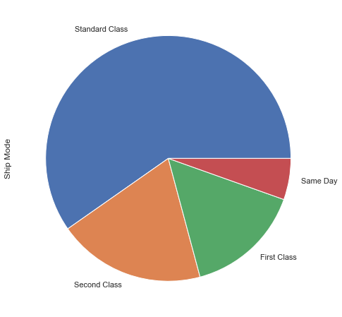

```python
df['Ship Mode'].value_counts().plot(kind='pie', figsize=(8,8));
```

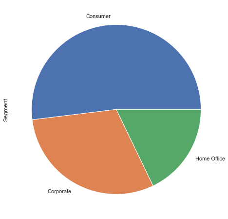

```python
df['Segment'].value_counts().plot(kind='pie', figsize=(8,8));
```

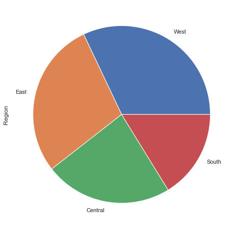

```python
df['Region'].value_counts().plot(kind='pie', figsize=(8,8));
```

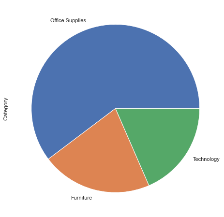

```python
df['Category'].value_counts().plot(kind='pie', figsize=(8,8));
```

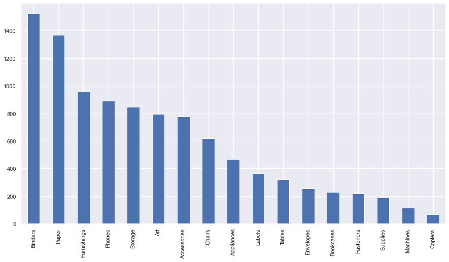

```python
df['Sub-Category'].value_counts().plot(kind='bar', figsize=(15,8));
```

### Analysis & Visualizations

**The analysis is structured as partitions, each part will focus on one independent variable with one or more dependent variables, and discuss their relation and how the first one affect the other.**

**The structure as followes:**

1. Profit & Sales Analysis
2. Segment Analysis
3. Category & Sub-Category Analysis
4. Ship Mode Analysis
5. Quantity & Discount Analysis
6. Location Analysis

#### Setting up some Visualizations Characterstics

```python
font_size1 = 18
font_size2 = 14
```

```python
df.head()
```

|  | Ship Mode | Segment | Country | City | State | Postal Code | Region | Category | Sub-Category | Sales | Quantity | Discount | Profit |
| --- | --- | --- | --- | --- | --- | --- | --- | --- | --- | --- | --- | --- | --- |
| 0 | Second Class | Consumer | United States | Henderson | Kentucky | 42420 | South | Furniture | Bookcases | 261.9600 | 2 | 0.00 | 41.9136 |
| 1 | Second Class | Consumer | United States | Henderson | Kentucky | 42420 | South | Furniture | Chairs | 731.9400 | 3 | 0.00 | 219.5820 |
| 2 | Second Class | Corporate | United States | Los Angeles | California | 90036 | West | Office Supplies | Labels | 14.6200 | 2 | 0.00 | 6.8714 |
| 3 | Standard Class | Consumer | United States | Fort Lauderdale | Florida | 33311 | South | Furniture | Tables | 957.5775 | 5 | 0.45 | -383.0310 |
| 4 | Standard Class | Consumer | United States | Fort Lauderdale | Florida | 33311 | South | Office Supplies | Storage | 22.3680 | 2 | 0.20 | 2.5164 |

### Profit & Sales Analysis

```python
print('Total Sales : ',np.round(df['Sales'].sum(),decimals=1),'\nAverage Sales : ',np.round(df['Sales'].mean(),decimals=1))
```

```
Total Sales :  2297200.9
Average Sales :  229.9
```

```python
print('Total Profit : ',np.round(df[df['Profit']>=0]['Profit'].sum(),decimals=1),'\nTotal Loss : ',np.round(df[df['Profit']<0]['Profit'].sum(),decimals=1))
print('Average Profit : ',np.round(df[df['Profit']>=0]['Profit'].mean(),decimals=1),'\nAverage Loss : ',np.round(df[df['Profit']<0]['Profit'].mean(),decimals=1))
```

```
Total Profit :  442528.3
Total Loss :  -156131.3
Average Profit :  54.5
Average Loss :  -83.4
```

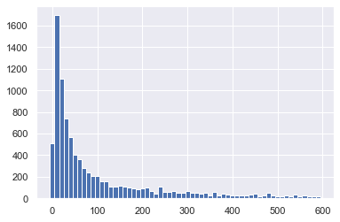

```python
bins = np.arange(-5,600,10)
plt.hist(data = df, x='Sales', bins=bins);
```

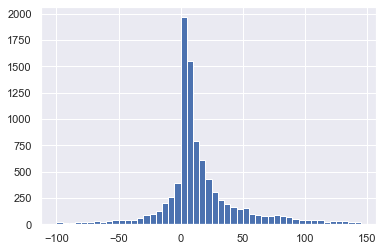

```python
bins = np.arange(-100,150,5)
plt.hist(data = df, x='Profit', bins=bins);
```

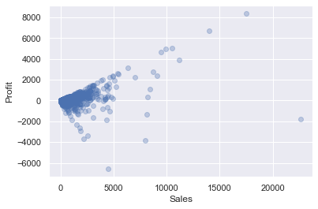

```python
sb.regplot(data = df, x ='Sales', y ='Profit', x_jitter = 0.04, scatter_kws = {'alpha':3/10}, fit_reg = False);
```

========================================================================================================================

### Segment Analysis

#### Segments Types

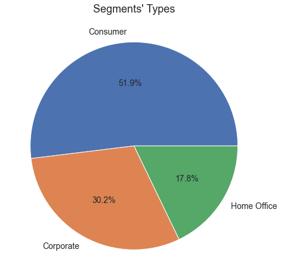

```python
df['Segment'].value_counts().plot(kind='pie', figsize=(8,8),autopct='%1.1f%%', fontsize=font_size2);
plt.title("Segments' Types", fontsize=font_size1)
plt.ylabel('');
```

As the graph clearly views the diffirent types of segments and the percentage of each one. Consumer is the highest segment, 51.9% of the company customers are consumers and it shows that the company depend on this segment as the main source of profit.

#### Order of Segments based on Sales

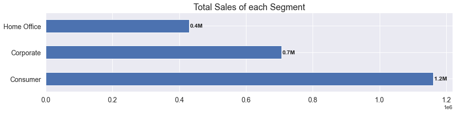

```python
df.groupby('Segment')['Sales'].sum().nlargest().plot(kind='barh', figsize=(15,3), fontsize=font_size2);
plt.title('Total Sales of each Segment', fontsize=font_size1)
plt.ylabel('');

for num, value in enumerate(df.groupby('Segment')['Sales'].sum().nlargest()):
    plt.text(value+2000, num, str(np.round(value/1000000, decimals = 1))+'M', fontweight='bold', va = 'center');
```

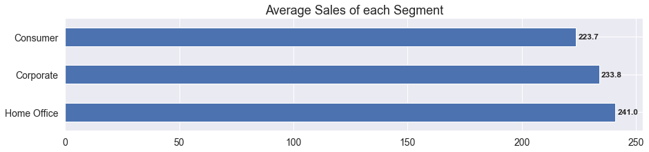

```python
df.groupby('Segment')['Sales'].mean().nlargest().plot(kind='barh', figsize=(15,3), fontsize=font_size2);
plt.title('Average Sales of each Segment', fontsize=font_size1)
plt.ylabel('');

for num, value in enumerate(df.groupby('Segment')['Sales'].mean().nlargest()):
    plt.text(value+1, num, str(np.round(value, decimals = 1)), fontweight='bold', va = 'center');
```

Here we can get that the segment that has the highest **sales** rate is **Home Office Segment** even when it forms only 17.8% of the all segments and its total **sales** is less than half a million.

#### Order of Segments based on Profit

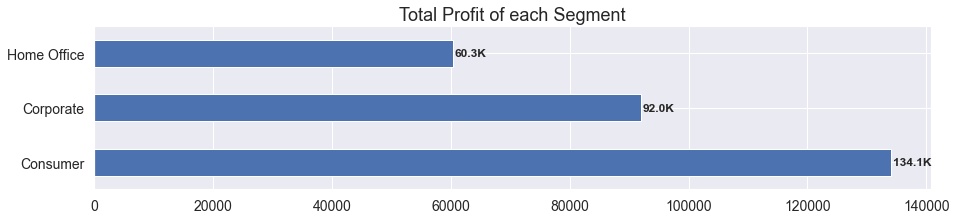

```python
df.groupby('Segment')['Profit'].sum().nlargest().plot(kind='barh', figsize=(15,3), fontsize=font_size2);
plt.title('Total Profit of each Segment', fontsize=font_size1);
plt.ylabel('');

for num, value in enumerate(df.groupby('Segment')['Profit'].sum().nlargest()):
    plt.text(value+300, num, str(np.round(value/1000, decimals = 1))+'K', fontweight='bold', va = 'center');
```

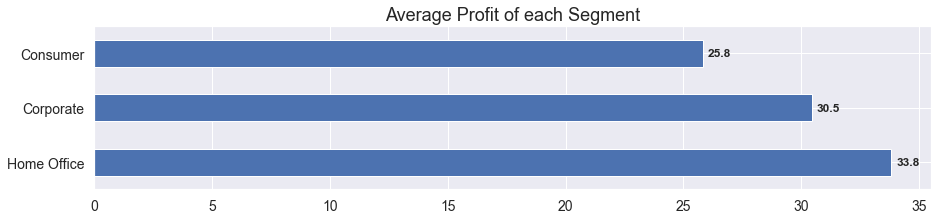

```python
df.groupby('Segment')['Profit'].mean().nlargest().plot(kind='barh', figsize=(15,3), fontsize=font_size2);
plt.title('Average Profit of each Segment', fontsize=font_size1);
plt.ylabel('');

for num, value in enumerate(df.groupby('Segment')['Profit'].mean().nlargest()):
    plt.text(value+0.2, num, str(np.round(value, decimals = 1)), fontweight='bold', va = 'center');
```

Here we can get that the segment that has the highest **profit** rate is **Home Office Segment** even when it forms only 17.8% of the all segments and its total **profit** is less than 100K.

#### Segments under Profit & Sales

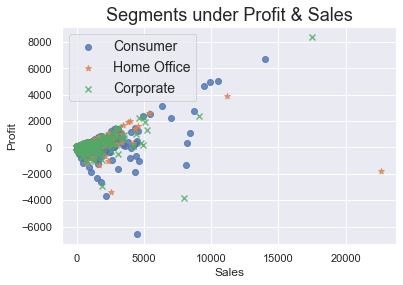

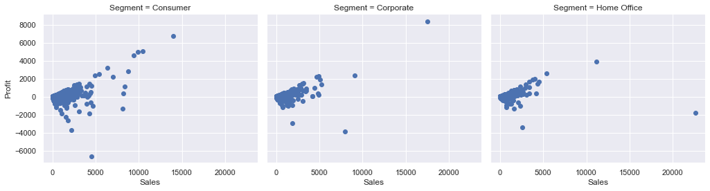

```python
Segments_Markers = [['Consumer','o'], ['Home Office','*'], ['Corporate','x']]

for Segment, Marker in Segments_Markers:
    plotdata = df[df['Segment']==Segment]
    sb.regplot(data = plotdata, x ='Sales', y ='Profit', x_jitter = 0.04, scatter_kws = {'alpha':8/10}, fit_reg = False, marker=Marker)
plt.legend(['Consumer', 'Home Office','Corporate'], fontsize=font_size2);
plt.title('Segments under Profit & Sales', fontsize=font_size1)

graph = sb.FacetGrid(data = df, col='Segment', size = 4, aspect =1.2, col_wrap = 3);
graph.map(plt.scatter,'Sales','Profit');
```

Here we can get a summary of how the segments variate according to **sales and profit** and can notice the range of each segment and the common area of sales an profit.

========================================================================================================================

### Category & Sub-Category Analysis

#### Categories

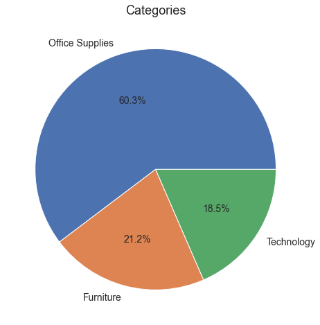

```python
df['Category'].value_counts().plot(kind='pie', figsize=(8,8),autopct='%1.1f%%', fontsize=font_size2);
plt.title("Categories", fontsize=font_size1)
plt.ylabel('');
```

#### Category by Average Sales

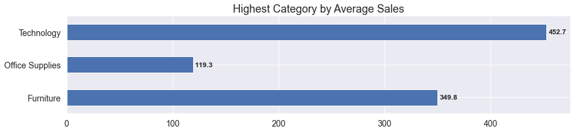

```python
df.groupby(['Category'])['Sales'].mean().plot(kind='barh', figsize=(15,3), fontsize=font_size2);
plt.title('Highest Category by Average Sales', fontsize=font_size1)
plt.ylabel('');

for num, value in enumerate(df.groupby(['Category'])['Sales'].mean()):
    plt.text(value+2, num, str(np.round(value, decimals = 1)), fontweight='bold', va = 'center');
```

#### Category by Average Profit

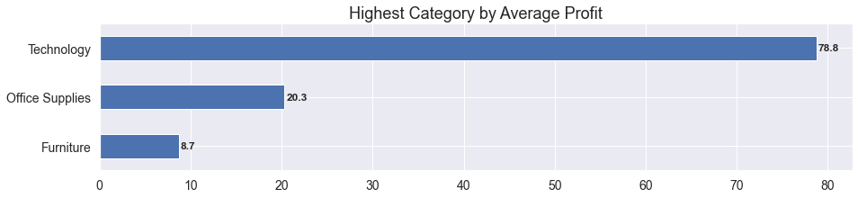

```python
df.groupby(['Category'])['Profit'].mean().plot(kind='barh', figsize=(15,3), fontsize=font_size2);
plt.title('Highest Category by Average Profit', fontsize=font_size1)
plt.ylabel('');

for num, value in enumerate(df.groupby(['Category'])['Profit'].mean()):
    plt.text(value+0.2, num, str(np.round(value, decimals = 1)), fontweight='bold', va = 'center');
```

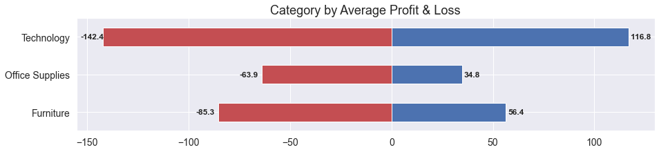

```python
df[df['Profit']>=0].groupby('Category')['Profit'].mean().plot(kind='barh',figsize=(15,3), fontsize=font_size2);
df[df['Profit']<0].groupby('Category')['Profit'].mean().plot(kind='barh',color='r');
plt.title('Category by Average Profit & Loss', fontsize=font_size1)
plt.ylabel('');

for num, value in enumerate(df[df['Profit']>=0].groupby('Category')['Profit'].mean()):
    plt.text(value+1, num, str(np.round(value, decimals = 1)), fontweight='bold', va = 'center');

for num, value in enumerate(df[df['Profit']<0].groupby('Category')['Profit'].mean()):
    plt.text(value-11, num, str(np.round(value, decimals = 1)), fontweight='bold', va = 'center', ha='left');
```

#### Highest Categories by Average Sales

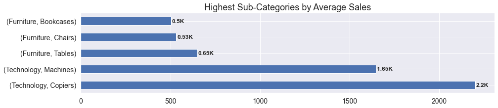

```python
df.groupby(['Category', 'Sub-Category'])['Sales'].mean().nlargest(5).plot(kind='barh', figsize=(15,3), fontsize=font_size2);
plt.title('Highest Sub-Categories by Average Sales', fontsize=font_size1)
plt.ylabel('');

for num, value in enumerate(df.groupby(['Category', 'Sub-Category'])['Sales'].mean().nlargest(5)):
    plt.text(value+5, num, str(np.round(value/1000, decimals = 2))+'K', fontweight='bold', va = 'center');
```

#### Highest Categories by Average Profit

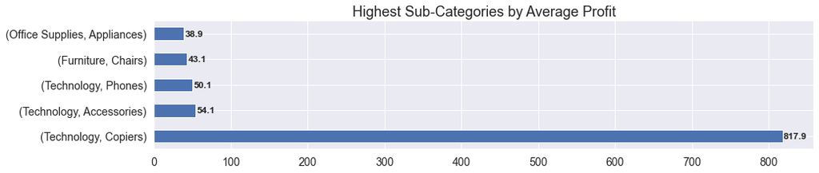

```python
df.groupby(['Category', 'Sub-Category'])['Profit'].mean().nlargest(5).plot(kind='barh', figsize=(15,3), fontsize=font_size2);
plt.title('Highest Sub-Categories by Average Profit', fontsize=font_size1)
plt.ylabel('');

for num, value in enumerate(df.groupby(['Category', 'Sub-Category'])['Profit'].mean().nlargest(5)):
    plt.text(value+1, num, str(np.round(value, decimals =1)), fontweight='bold', va = 'center');
```

#### Lowest Categories by Average Profit

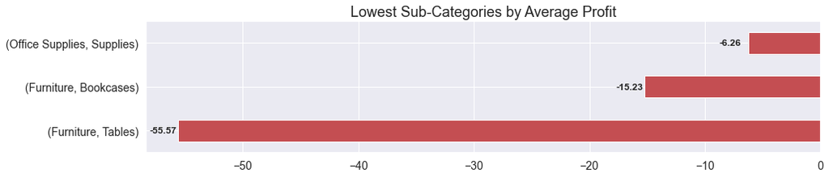

```python
df.groupby(['Category', 'Sub-Category'])['Profit'].mean().nsmallest(3).plot(kind='barh', figsize=(15,3), fontsize=font_size2, color='r');
plt.title('Lowest Sub-Categories by Average Profit', fontsize=font_size1)
plt.ylabel('');

for num, value in enumerate(df.groupby(['Category', 'Sub-Category'])['Profit'].mean().nsmallest(3)):
    plt.text(value-2.5, num, str(np.round(value, decimals = 2)), fontweight='bold', va = 'center', ha='left');
```

#### Categories under Profit & Sales

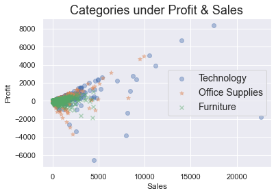

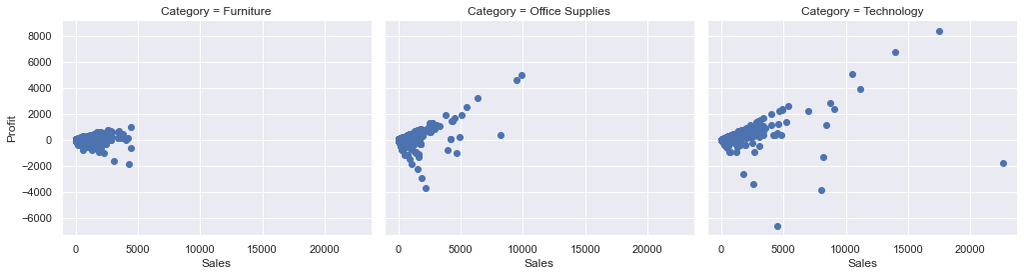

```python
Categories_Markers = [['Technology','o'], ['Office Supplies','*'], ['Furniture','x']]

for Category, Marker in Categories_Markers:
    plotdata = df[df['Category']==Category]
    sb.regplot(data = plotdata, x ='Sales', y ='Profit', x_jitter = 0.04, scatter_kws = {'alpha':4/10}, fit_reg = False, marker=Marker);
plt.legend( ['Technology','Office Supplies','Furniture'], fontsize=font_size2);
plt.title('Categories under Profit & Sales', fontsize=font_size1)

q = sb.FacetGrid(data = df, col='Category', size = 4, aspect =1.2, col_wrap = 3);
q.map(plt.scatter,'Sales','Profit');
```

#### Sub-Categories under Profit & Sales

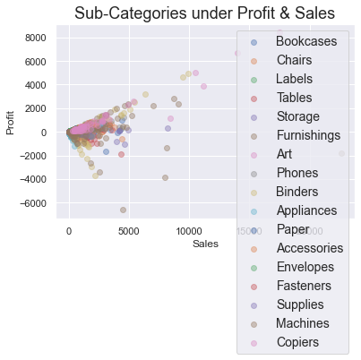

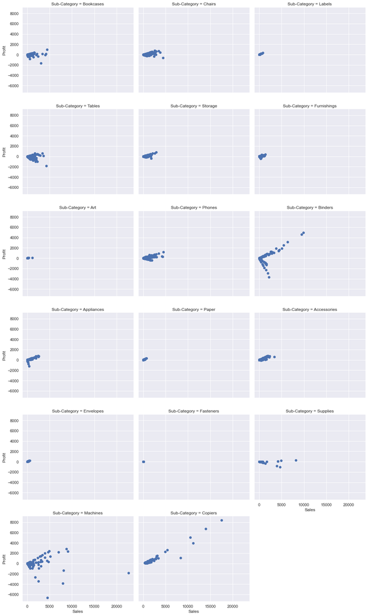

```python
Sub_Categories = df['Sub-Category'].unique()

for i, Sub_Category in enumerate(Sub_Categories):
    plotdata = df[df['Sub-Category']==Sub_Categories[i]]
    sb.regplot(data = plotdata, x ='Sales', y ='Profit', x_jitter = 0.04, scatter_kws = {'alpha':4/10}, fit_reg = False);
plt.legend(Sub_Categories, fontsize=font_size2);
plt.title('Sub-Categories under Profit & Sales', fontsize=font_size1)

q = sb.FacetGrid(data = df, col='Sub-Category', size = 4, aspect =1.2, col_wrap = 3);
q.map(plt.scatter,'Sales','Profit');
```